# Practical 2

In this practical session, we use MR to evaluate the causal effect of HDL choleterol on CAD, with a focus on the pleiotropy issue.

# Package installation

```r
# library(devtools)
# devtools::install_github('MRCIEU/TwoSampleMR')

# install_github("qingyuanzhao/mr.raps") ## if you have problem installing the rsnps dependence package for mr.raps, you can try:
# install_github("ropensci/rsnps")

# install_github("jingshuw/GRAPPLE")
# install_github("rondolab/MR-PRESSO")
# install.packages("MendelianRandomization")
```

# Data proprocessing

We use TwoSampleMR to obtain the GWAS summary statistics as introduced in Lecture 1.

```r
library(TwoSampleMR)
## Exposure trait: GLGC HDL-cholesterol GWAS data (2013)
exposure_dat <- extract_instruments("ieu-a-780", p1 = 1e-8, clump = T)
```

```
## API: public: http://gwas-api.mrcieu.ac.uk/
```

```r
## Outcome trait: CAD data as in practical session 1
outcome_dat <- extract_outcome_data(exposure_dat$SNP, "ieu-a-7")
```

```
## Extracting data for 39 SNP(s) from 1 GWAS(s)
```

```r
dat <- harmonise_data(exposure_dat, outcome_dat)
```

```
## Harmonising  || id:ieu-a-780 (ieu-a-780) and Coronary heart disease || id:ieu-a-7 (ieu-a-7)
```

Note: TwoSampleMR package provides the easiest way to start your MR analysis, but may not be the best choice:

- This approach can possibly suffer from p-value selection bias even if we use genome-wide significance threshold. To avoid SNP selection bias, especially if we want to lower the p-value threshold and include weaker SNPs, one may use a three-sample MR design, as will be discussed in Lecture 4
- This approach does not support estimating the shared SNP correlation matrix across traits when there are overlapping samples. We will need the whole GWAS summary statistics for this purpose.
- Some methods, such as CAUSE, MRMix and GRAPPLE, may prefer their own data preprocessing steps introduced in the tutorials of these methods

# Diagnosis for pleiotropic effects

## Q statistics

```r
mr_heterogeneity(dat)
```

| id.exposure | id.outcome | outcome | exposure | method | Q | Q_df | Q_pval |
| --- | --- | --- | --- | --- | --- | --- | --- |
| ieu-a-780 | ieu-a-7 | Coronary heart disease \|\| id:ieu-a-7 | \|\| id:ieu-a-780 | MR Egger | 257.4834 | 37 | 7.860171e-35 |
| ieu-a-780 | ieu-a-7 | Coronary heart disease \|\| id:ieu-a-7 | \|\| id:ieu-a-780 | Inverse variance weighted | 273.3688 | 38 | 2.168185e-37 |

The large Q statistics indicates existance of pleiotropic effects.

## Residual plot

We compare $t_j$ with standard Gaussian quantiles, showing $|t_j|$

```r
# install_github("ropensci/rsnps")
# install_github("qingyuanzhao/mr.raps")
library(mr.raps)
out1 <- mr.raps(dat, over.dispersion = F)
```

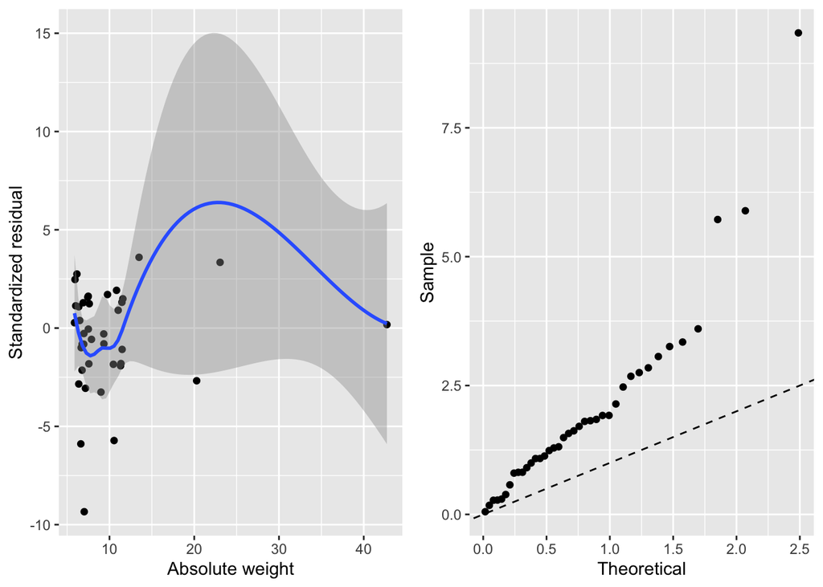

```
## Estimated causal effect: -0.164, standard error: 0.0291, p-value: 1.66e-08.
## Estimated overdispersion variance: 0, standard error: 0, p-value: NaN.
## ANOVA test: are the weights and residuals independent?
## Analysis of Variance Table
##
## Response: std.resids
##                                                       Df  Sum Sq Mean Sq
## bs(weights, knots = quantile(weights, 1:df/(df + 1)))  6  35.403  5.9004
## Residuals                                             33 237.611  7.2003
##                                                       F value Pr(>F)
## bs(weights, knots = quantile(weights, 1:df/(df + 1)))  0.8195 0.5629
## Residuals
```

The residual plot indicates pervasive pleiotropy

## GRAPPLE visualization to check for correlated pleiotropy

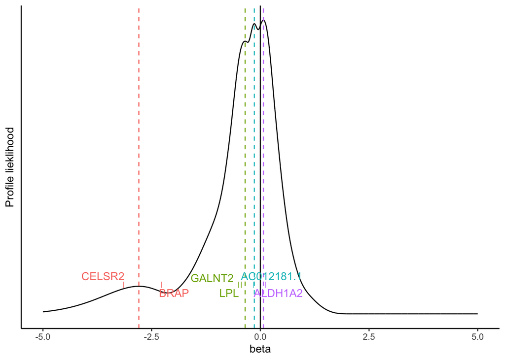

```r
library(GRAPPLE)
data <- data.frame(SNP = dat$SNP, gamma_exp1 = dat$beta.exposure,
                   se_exp1 = dat$se.exposure, gamma_out1 = dat$beta.outcome,
                   se_out1 = dat$se.outcome)
row.names(data) <- data$SNP
diagnosis <- findModes(data, map.marker = T)
diagnosis$p
```

Above figure shows possible pleiotropic pathways that are related to other lipid traits

# Comparison of results between different methods

## Five methods that are available in the TwoSampleMR package

IVW, Weighted median, MR-Egger, Weighted mode (MBE), MR-RAPS

```r
out <- mr(dat, method_list = c("mr_ivw", "mr_weighted_median", "mr_egger_regression",
                               "mr_weighted_mode", "mr_raps"))
```

```
## Analysing 'ieu-a-780' on 'ieu-a-7'
```

```r
out[, -(1:4)]
```

| method | nsnp | b | se | pval |
| --- | --- | --- | --- | --- |
| Inverse variance weighted | 39 | -0.1972706 | 0.07397029 | 0.007655682 |
| Weighted median | 39 | -0.1447091 | 0.04791572 | 0.002527120 |
| MR Egger | 39 | -0.0241618 | 0.13572258 | 0.859675687 |
| Weighted mode | 39 | -0.1184067 | 0.05253133 | 0.030043024 |
| Robust adjusted profile score (RAPS) | 39 | -0.1586866 | 0.06746323 | 0.018663040 |

```r
#mr_scatter_plot(out, dat)
```

## MR-PRESSO

```r
## devtools::install_github("rondolab/MR-PRESSO")
library(MRPRESSO)

result <- mr_presso(BetaOutcome = "beta.outcome", BetaExposure = "beta.exposure",
          SdOutcome = "se.outcome", SdExposure = "se.exposure", data = dat,
          OUTLIERtest = T, DISTORTIONtest = T)
outlier.idx <- result$`MR-PRESSO results`$`Distortion Test`$`Outliers Indices`
outlier.idx
```

```
## [1]  2  4  7 22 36
```

```r
result$`Main MR results`
```

| Exposure | MR Analysis | Causal Estimate | Sd | T-stat | P-value |
| --- | --- | --- | --- | --- | --- |
| beta.exposure | Raw | -0.1972706 | 0.07397029 | -2.666890 | 0.0111853713 |
| beta.exposure | Outlier-corrected | -0.1984163 | 0.05115370 | -3.878826 | 0.0004739419 |

Which points are detected as outliers?

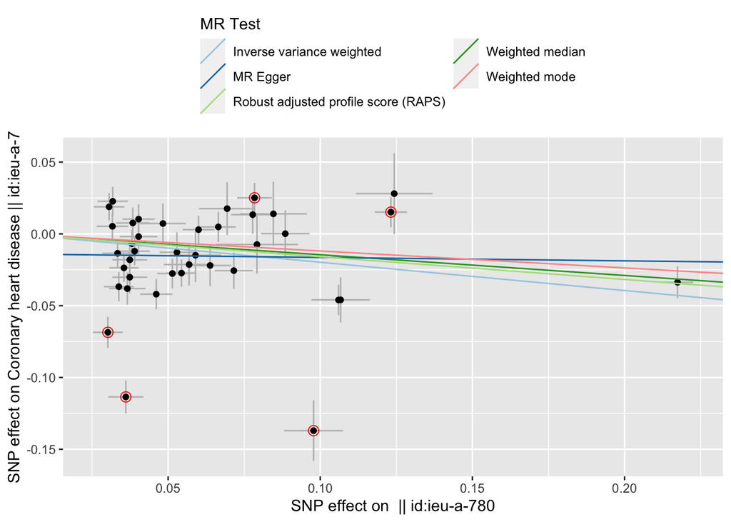

```r
library(ggplot2)
outliers <- dat[outlier.idx, c('beta.exposure', 'beta.outcome')]
outliers <- sign(outliers[, 1]) * outliers
mr_scatter_plot(out, dat)[[1]] + geom_point(data = outliers, aes(x = beta.exposure,
                                                y = beta.outcome), colour = "red",
                                            size = 3, shape = 1)
```

## Contamination mixture

```r
library(MendelianRandomization)
MR_input <- mr_input(bx = dat$beta.exposure,
                   bxse = dat$se.exposure, by = dat$beta.outcome,
                   byse = dat$se.outcome)
result <- mr_conmix(MR_input)
result
```

```
##
## Contamination mixture method
## (Standard deviation of invalid estimands = 1.09355)
##
## Number of Variants : 39
## ------------------------------------------------------------------
##  Method Estimate 95% CI
##  ConMix    -0.10 -0.44, -0.35
##                  -0.23,  0.20
## ------------------------------------------------------------------
## Note: confidence interval contains multiple ranges of values.
```

The confidence interval for the HDL-C effect is $[-0.44, -0.35]\cup [-0.23, 0.2]$ which contains $0$.

We can adjust for other lipid traits using multivariable MR. Examples will be shown in Lecture 4.